# Multivariate Classification of Contraceptive Method Choice

Violet Buxton-Walsh | COMPSCI C100, Principles & Techniques of Data Science | May 13, 2020

```python
#Standard Data Science Libraries
import pandas as pd
import seaborn as sns
from matplotlib import pyplot as plt
import matplotlib.ticker as plticker
import numpy as np

#Standard ML Libraries
from sklearn.model_selection import train_test_split
from sklearn.model_selection import cross_val_score

#Standard Random Forest and Hyperparameter Tuning Libraries
from sklearn.ensemble import RandomForestClassifier
from sklearn.ensemble import RandomForestRegressor
from sklearn.model_selection import RandomizedSearchCV
from sklearn.model_selection import GridSearchCV

#Misc.
from sklearn import metrics
from pprint import pprint
```

```python
#Import the data
data = pd.read_csv('CMCtxt.txt', header = None)

#Apply minimal data cleaning, seeing no NaN values continue with modeling
cmc = data.rename(columns={0: 'wife_age_num', 1: 'wife_ed_cat', 2: 'hus_ed_cat', 3: 'kids_num', 4:
                           'wife_rel_bi', 5: 'wife_work_bi', 6: 'hus_occ_cat', 7: 'SOL_cat', 8: 'media_ex_bi',
                           9: 'cmc_attr'})
cmc.head()
```

|  | wife_age_num | wife_ed_cat | hus_ed_cat | kids_num | wife_rel_bi | wife_work_bi | hus_occ_cat | SOL_cat | media_ex_bi | cmc_attr |
| --- | --- | --- | --- | --- | --- | --- | --- | --- | --- | --- |
| 0 | 24 | 2 | 3 | 3 | 1 | 1 | 2 | 3 | 0 | 1 |
| 1 | 45 | 1 | 3 | 10 | 1 | 1 | 3 | 4 | 0 | 1 |
| 2 | 43 | 2 | 3 | 7 | 1 | 1 | 3 | 4 | 0 | 1 |
| 3 | 42 | 3 | 2 | 9 | 1 | 1 | 3 | 3 | 0 | 1 |
| 4 | 36 | 3 | 3 | 8 | 1 | 1 | 3 | 2 | 0 | 1 |

Perform exploratory data analysis (EDA) and include in your report at least two data visualizations. Focus on the question: What are the factors that best determine the type of contraceptive used? What are the relationships between other factors which may affect contraceptive use.

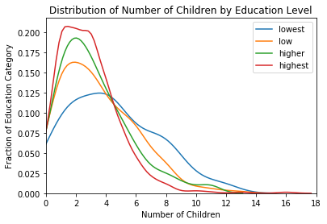

```python
#Do higher educated women have less or more children than women with other education levels?

sns.kdeplot(cmc[cmc['wife_ed_cat'] == 1]['kids_num'], label = 'lowest')
sns.kdeplot(cmc[cmc['wife_ed_cat'] == 2]['kids_num'], label = 'low')
sns.kdeplot(cmc[cmc['wife_ed_cat'] == 3]['kids_num'], label = 'higher')
sns.kdeplot(cmc[cmc['wife_ed_cat'] == 4]['kids_num'], label = 'highest')
plt.xlim(0,18)

plt.title('Distribution of Number of Children by Education Level')
plt.xlabel('Number of Children')
plt.ylabel('Fraction of Education Category')
plt.legend()
plt.figure(figsize = (20,20))
plt.savefig('EDA-1')
plt.show()
```

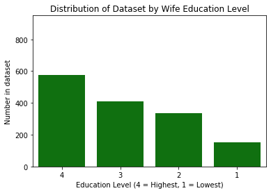

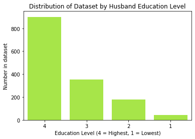

```python
#Do we have mostly high educated women in this dataset, or mostly low educated women?

wife_ed_dist = pd.DataFrame(cmc['wife_ed_cat'].value_counts())
wife_ed_dist = wife_ed_dist.transpose()
sns.barplot(data = wife_ed_dist, color = 'green')

plt.title('Distribution of Dataset by Wife Education Level')
plt.xlabel('Education Level (4 = Highest, 1 = Lowest)')
plt.ylabel('Number in dataset')
plt.ylim(0,950)
plt.show()

#Do we have mostly high educated men in this dataset, or mostly low educated women?

hus_ed_dist = pd.DataFrame(cmc['hus_ed_cat'].value_counts())
hus_ed_dist = hus_ed_dist.transpose()
sns.barplot(data = hus_ed_dist, color = 'greenyellow')

plt.title('Distribution of Dataset by Husband Education Level')
plt.xlabel('Education Level (4 = Highest, 1 = Lowest)')
plt.ylabel('Number in dataset')
plt.ylim(0,950)
plt.show()
```

I consider the distribution of indivduals into different education levels within the data set in order to determine if all levels are equally represented, they are not. Instead, I think to consider combined education level of husband and wife, and wonder if this is more important than the individual level of both.

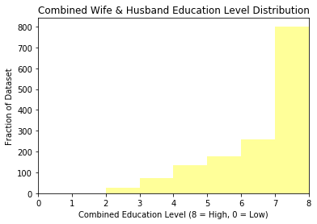

```python
#compare the distribution of
sns.distplot(cmc['wife_ed_cat'] + cmc['hus_ed_cat'], color = 'yellow', hist = True, kde = False, bins = [0,1,2,3,4,5,6,7,8])

plt.title('Combined Wife & Husband Education Level Distribution')
plt.xlabel('Combined Education Level (8 = High, 0 = Low)')
plt.ylabel('Fraction of Dataset')
plt.xlim(0,8)
plt.savefig('EDA-4')
plt.show()

#(cmc['wife_ed_cat'] + cmc['hus_ed_cat']).value_counts()
```

```python
#Contraceptive method choice for muslim and non-muslim women
#Data set up

Is_cmc = pd.DataFrame(cmc[cmc['wife_rel_bi'] == 1]['cmc_attr'].value_counts())
Not_Is_cmc = pd.DataFrame(cmc[cmc['wife_rel_bi'] == 0]['cmc_attr'].value_counts())
Not_Is_cmc = Not_Is_cmc.rename(columns = {'cmc_attr':'not_islam'})
Not_Is_cmc['islam'] = Is_cmc
Not_Is_cmc = Not_Is_cmc.reset_index()
cmc_rel = Not_Is_cmc.rename(columns = {'index':'cmc'})
```

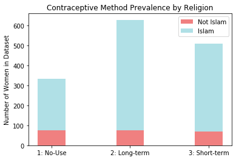

```python
#Plot of contraceptive method choice for muslim and non-muslim women
N = 3
not_IS = (76, 75, 69)
IS = (257, 554, 442)

#X locations for the groups
ind = np.arange(N)
#The width of the bars
width = 0.35

p1 = plt.bar(ind, not_IS, width, color = 'lightcoral')
p2 = plt.bar(ind, IS, width, bottom=not_IS, color = 'powderblue')

plt.ylabel('Number of Women in Dataset')
plt.title('Contraceptive Method Prevalence by Religion')
plt.xticks(ind, ('1: No-Use','2: Long-term','3: Short-term'))
plt.legend((p1[0], p2[0]), ('Not Islam', 'Islam'))
plt.show()
```

Examining the relationship between religion and contraceptive use, I find that the data set is predominantly consistent of muslim women (the majority religion in Indonesia), making it too difficult to asses whether these trends are broadly based on demogrphics or if they have a specific link to religion. This line of inquiry is not considered further.

```python
#Media exposure relative to standard of living
#Data set up

bad_ex = pd.DataFrame(cmc[cmc['media_ex_bi'] == 1]['SOL_cat'].value_counts())
good_ex = pd.DataFrame(cmc[cmc['media_ex_bi'] == 0]['SOL_cat'].value_counts())
good_ex['bad_ex'] = bad_ex
good_ex = good_ex.reset_index()
good_ex = good_ex.rename(columns = {'SOL_cat':'good_ex'})

cmc_ex = good_ex.rename(columns = {'index':'SOL'})
#cmc_ex['scaled_good'] =
cmc_ex.iloc[:1,1:3] = cmc_ex.iloc[:1,1:3]/684
cmc_ex.iloc[1:2,1:3] = cmc_ex.iloc[1:2,1:3]/431
cmc_ex.iloc[2:3,1:3] = cmc_ex.iloc[2:3,1:3]/229
cmc_ex.iloc[3:4,1:3] = cmc_ex.iloc[3:4,1:3]/129
```

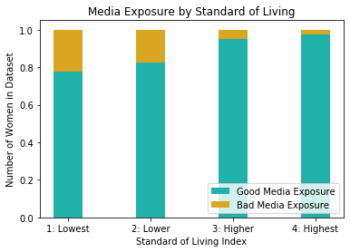

```python
#Plot of media expsure versus standard of living index
N2 = 4
good = (0.7752, 0.8253, 0.9490, 0.9737)
bad = (0.2248, 0.1747, 0.0510, 0.0263 )

ind2 = np.arange(N2)    # the x locations for the groups
width = 0.35       # the width of the bars: can also be len(x) sequence

p1 = plt.bar(ind2, good, width, color = 'lightseagreen')
p2 = plt.bar(ind2, bad, width, bottom=good, color = 'goldenrod')

plt.ylabel('Number of Women in Dataset')
plt.xlabel('Standard of Living Index')
plt.title('Media Exposure by Standard of Living')
plt.xticks(ind2, ('1: Lowest','2: Lower','3: Higher','4: Highest'))
plt.legend((p1[0], p2[0]), ('Good Media Exposure', 'Bad Media Exposure'), loc = 4)

plt.savefig('EDA-5')
plt.show()
```

I investigate the relationship between standard of living and media exposure (scaled by population in each SOL category), and find that as expected, women of lower SOLs are less likely to have 'good' media exposure. However, most women overall have what is considered 'good' media exposure, so I wonder if the consideration of 'good' versus 'bad' is a particularly useful indicator. Later, I find media exposure has a stronger correlation with contraceptive method choice than with many other attributes, and include it in my final model.

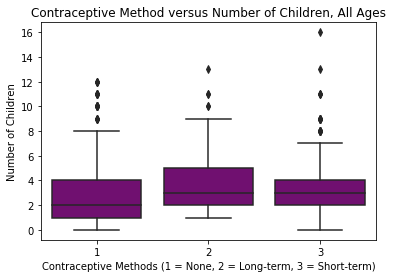

[figure not shown]

```python
#What are the factors that best determine the type of contraceptive used?
#Compare cmc_attr and number of kids

sns.boxplot(x = cmc['cmc_attr'], y = cmc['kids_num'], color = 'purple')

plt.title('Contraceptive Method versus Number of Children, All Ages')
plt.xlabel('Contraceptive Methods (1 = None, 2 = Long-term, 3 = Short-term)')
plt.ylabel('Number of Children')
plt.show()

#What are the factors that best determine the type of contraceptive used?
#Compare cmc_attr and number of kids FOR WOMEN UNDER 40
childbearing = []
for i in cmc['wife_age_num'].values:
    if i in range(40,50):
        childbearing.append(1)
    else:
        childbearing.append(0)
cmc['childbearing_bi'] = childbearing


sns.boxplot(x = cmc[cmc['childbearing_bi']==1]['cmc_attr'], y = cmc[cmc['childbearing_bi']==1]['kids_num'], color = 'palevioletred')

plt.title('Contraceptive Method versus Number of Children, Women Under 40')
plt.xlabel('Contraceptive Methods (1 = None, 2 = Long-term, 3 = Short-term)')
plt.ylabel('Number of Children')
plt.show()
```

From this image, I consider that there is some relationship between age and contraceptive use, and add the binary features of 'older_bi' and 'childbering_bi' to indicate if a woman is above 40 or within the age range of 20-30, and note that.

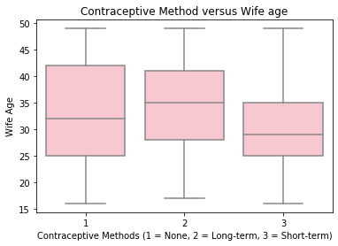

```python
#What are the factors that best determine the type of contraceptive used?
#Compare cmc_attr and wife's age

sns.boxplot(x = cmc['cmc_attr'], y = cmc['wife_age_num'], color = 'pink')

plt.title('Contraceptive Method versus Wife age')
plt.xlabel('Contraceptive Methods (1 = None, 2 = Long-term, 3 = Short-term)')
plt.ylabel('Wife Age')
plt.savefig('report3.svg')
plt.show()
```

The median age of contraceptive users increases moving from short-term users, to lack of use, to long-term contraceptive users. This is an interesting finding implying that contracpetive methods may vary greatly depending on when in her life a woman is. I am interested enough, and find the correlation strong enough, that I invetigate this relationship further below.

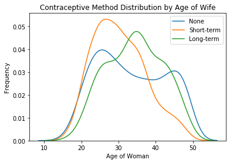

```python
#See how the type of contraceptive used varies with age
no_cmc = cmc[cmc['cmc_attr']==1]['wife_age_num']
short_cmc = cmc[cmc['cmc_attr']==3]['wife_age_num']
long_cmc = cmc[cmc['cmc_attr']==2]['wife_age_num']

sns.kdeplot(no_cmc, label = 'None')
sns.kdeplot(short_cmc, label = 'Short-term')
sns.kdeplot(long_cmc, label = 'Long-term')

plt.title('Contraceptive Method Distribution by Age of Wife')
plt.xlabel('Age of Woman')
plt.ylabel('Frequency')
plt.savefig('report4.png')
```

Seeing the above image, I notice clear trends in the type of contraceptive used based on a woman's age. As with the corresponding box plot above, younger women appear to primarily use short-term contraceptive methods while older women use long-term methods and the oldest women use no method. I wonder how socio-economic status might affect these and break down these trends by standard of living.

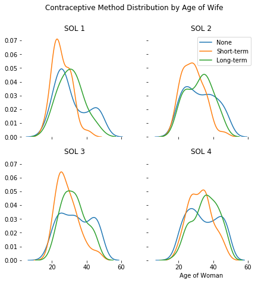

```python
#make subplots showing this distribution for different women's education levels
u = 'SOL_cat'

#SOL 1
f, axes = plt.subplots(2, 2, figsize=(7, 7), sharex=True,sharey=True)
sns.despine(left=True,bottom=True)

no_cmc = cmc[(cmc['cmc_attr']==1) & (cmc[u]==1)]['wife_age_num']
short_cmc = cmc[(cmc['cmc_attr']==3) & (cmc[u]==1)]['wife_age_num']
long_cmc = cmc[(cmc['cmc_attr']==2) & (cmc[u]==1)]['wife_age_num']

sns.kdeplot(no_cmc,ax=axes[0,0],legend=False)
sns.kdeplot(short_cmc,ax=axes[0,0],legend=False)
sns.kdeplot(long_cmc,ax=axes[0,0],legend=False)
axes[0,0].set_title('SOL 1')

#SOL 2
no_cmc = cmc[(cmc['cmc_attr']==1) & (cmc[u]==2)]['wife_age_num']
short_cmc = cmc[(cmc['cmc_attr']==3) & (cmc[u]==2)]['wife_age_num']
long_cmc = cmc[(cmc['cmc_attr']==2) & (cmc[u]==2)]['wife_age_num']

sns.kdeplot(no_cmc, label = 'None',ax=axes[0,1])
sns.kdeplot(short_cmc, label = 'Short-term',ax=axes[0,1])
sns.kdeplot(long_cmc, label = 'Long-term',ax=axes[0,1])
axes[0,1].set_title('SOL 2')

#SOL 3
no_cmc = cmc[(cmc['cmc_attr']==1) & (cmc[u]==3)]['wife_age_num']
short_cmc = cmc[(cmc['cmc_attr']==3) & (cmc[u]==3)]['wife_age_num']
long_cmc = cmc[(cmc['cmc_attr']==2) & (cmc[u]==3)]['wife_age_num']

sns.kdeplot(no_cmc, label = 'None',ax=axes[1,0], legend = False)
sns.kdeplot(short_cmc, label = 'Short-term',ax=axes[1,0], legend = False)
sns.kdeplot(long_cmc, label = 'Long-term',ax=axes[1,0], legend = False)
axes[1,0].set_title('SOL 3')
plt.xlabel('Age of Woman')

#SOL 4
no_cmc = cmc[(cmc['cmc_attr']==1) & (cmc[u]==4)]['wife_age_num']
short_cmc = cmc[(cmc['cmc_attr']==3) & (cmc[u]==4)]['wife_age_num']
long_cmc = cmc[(cmc['cmc_attr']==2) & (cmc[u]==4)]['wife_age_num']

sns.kdeplot(no_cmc, label = 'None',ax=axes[1,1], legend = False)
sns.kdeplot(short_cmc, label = 'Short-term',ax=axes[1,1], legend = False)
sns.kdeplot(long_cmc, label = 'Long-term',ax=axes[1,1], legend = False)
axes[1,1].set_title('SOL 4')
plt.xlabel('Age of Woman')

f.suptitle('Contraceptive Method Distribution by Age of Wife')
plt.savefig('report1.svg')
plt.show()
```

I see that the same trends from above hold across different standards of living, but interestingly, that contraceptive use seems to be discontinued earlier among women from lower standard of living categories. Furthermore, short-term methods outcompete other methods more dramatically for these women.

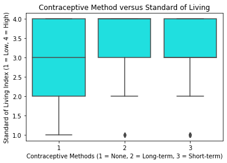

```python
#What are the factors that best determine the type of contraceptive used?
#Compare SOL index and contraceptive method
sns.boxplot(x = cmc['cmc_attr'], y = cmc['SOL_cat'], color = 'aqua')

plt.title('Contraceptive Method versus Standard of Living')
plt.xlabel('Contraceptive Methods (1 = None, 2 = Long-term, 3 = Short-term)')
plt.ylabel('Standard of Living Index (1 = Low, 4 = High)')
plt.savefig('EDA-8')
plt.show()
```

In another attempt at visualizing the relationship between contraceptive use and standard of living, I make this plot. This provides compelling evidence that women of lower SOL categories are more likely to use no contraceptives. However, there is a limitation in that I am cannot if the position of plot for method 1 (no use) is being weighed down by women in the lowest SOL category alone, or in some other combination of categories. This led me to consider that being in the lowest SOL may have some kind of outsized impact on access to contraceptives, and make a binary feature indicating this later on.

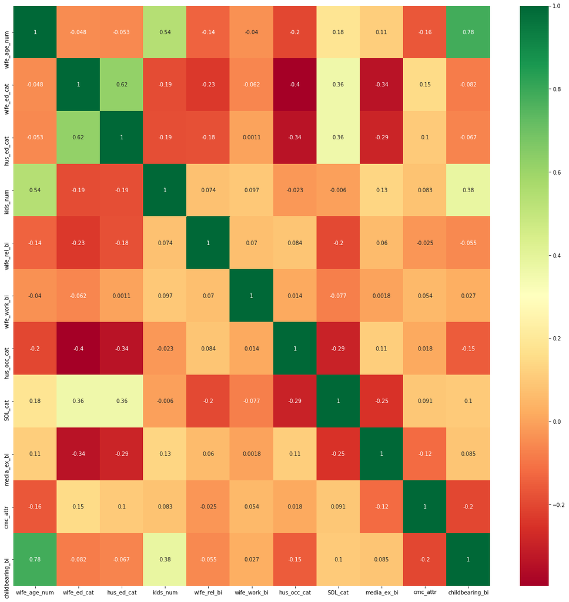

```python
#Select all features
X = cmc.iloc[:,0:9]
y = cmc.iloc[:,9]

#Get the correlations for each features combination in the dataset
corrmat = cmc.corr()
top_corr_features = corrmat.index
plt.figure(figsize=(20,20))

#Plot the heat map
g=sns.heatmap(cmc[top_corr_features].corr(),annot=True,cmap="RdYlGn")
```

```python
#feature accounting for combined husband and wife's education
cmc['combined_ed_cat'] = cmc['wife_ed_cat'] + cmc['hus_ed_cat']

#feature weighting the exact number of children more heavily for each extra child
#cmc['kids_num']**2 == not a better correlation w/ cmc_attr

#feature indicating extremely low standard of living
low_sol = []
for i in cmc['SOL_cat']:
    if i == 1:
        low_sol.append(1)
    else:
        low_sol.append(0)
cmc['low_sol'] = low_sol

#Create a feature indicating if the women is within the best years for childbearing
childbearing = []
for i in cmc['wife_age_num'].values:
    if i in range(20,30):
        childbearing.append(1)
    else:
        childbearing.append(0)
cmc['childbearing_bi'] = childbearing

#Create a feature indicating if the women is above 40
older = []
for i in cmc['wife_age_num'].values:
    if i >= 40:
        older.append(1)
    else:
        older.append(0)
cmc['older_bi'] = older

#Create a feature for log(number of childern)
log_vals = []
for i in cmc['kids_num']:
    if i != 0:
        log_vals.append(np.log(i))
    else:
        log_vals.append(0)
cmc['log_kids'] = log_vals
```

This cell creates features which indicate 1) if a woman is in the lowest SOL, 2) if a woman is between 20 and 30 years old, 3) if a woman is above 40, and 4) transforms the number of children with a log transform.

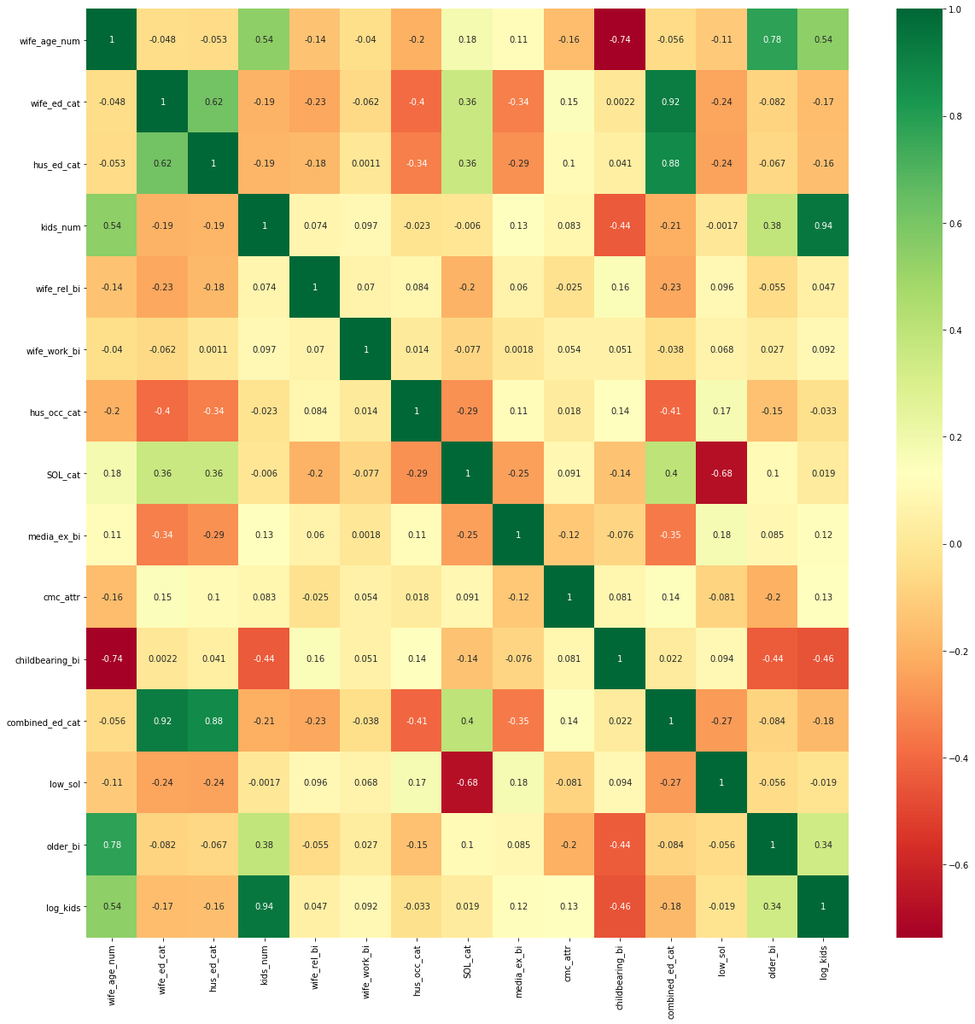

```python
X = cmc[['wife_age_num', 'wife_ed_cat', 'hus_ed_cat', 'kids_num', 'wife_rel_bi',
       'wife_work_bi', 'hus_occ_cat', 'SOL_cat', 'media_ex_bi', 'cmc_attr',
       'childbearing_bi', 'combined_ed_cat', 'low_sol', 'older_bi','log_kids']]
y = cmc['cmc_attr']

#get correlations of each features in dataset
corrmat = cmc.corr()
top_corr_features = corrmat.index
plt.figure(figsize=(20,20))
#plot heat map
g=sns.heatmap(cmc[top_corr_features].corr(),annot=True,cmap="RdYlGn")
```

Here I plot a second heat map displaying the correlation values for my new features. I decided to use these particular ones because they display stronger correlations with my attribute of interest ('cmc_attr', or contraceptive method) than many of the existing attributes.

```python
#OHE all categorical features
#exclude non-categorical (numerical) features:'wife_age_num', 'kids_num',

#Adjust this list to set which variables to one-hot-encode
#DO NOT MODIFY
cat_columns = ['wife_ed_cat', 'hus_ed_cat', 'wife_rel_bi', 'wife_work_bi',
               'hus_occ_cat', 'SOL_cat', 'media_ex_bi', 'combined_ed_cat','cmc_attr']
#OHE for test set
cmc_ohe = pd.get_dummies(cmc, prefix_sep="_",columns=cat_columns)
cat_dummies = [col for col in cmc_ohe if "_" in col and col.split("_")[0] in cat_columns]
cmcOHE = pd.get_dummies(cmc, prefix_sep="_", columns=cat_columns)
cmcOHE['cmc_attr'] = cmc['cmc_attr']
```

This cell uses one-hot-encoding to adjust categorical features accordingly. This is necessary because I tried many different models before settling on a Random Forest, and several of these require such a separation of categorical data.

```python
X = cmcOHE[['wife_age_num', 'kids_num', 'wife_rel_bi_0', 'wife_rel_bi_1',
            'low_sol', 'older_bi', 'log_kids', 'childbearing_bi',
       'wife_work_bi_0', 'wife_work_bi_1', 'hus_occ_cat_1', 'hus_occ_cat_2',
       'hus_occ_cat_3', 'hus_occ_cat_4', 'SOL_cat_1', 'SOL_cat_2', 'SOL_cat_3',
       'SOL_cat_4', 'media_ex_bi_0', 'media_ex_bi_1', 'combined_ed_cat_2',
       'combined_ed_cat_3', 'combined_ed_cat_4', 'combined_ed_cat_5',
       'combined_ed_cat_6', 'combined_ed_cat_7', 'combined_ed_cat_8']]
Y = cmcOHE[cmcOHE.columns[-1:]]

X_train,X_test,y_train,y_test=train_test_split(X,Y, test_size=0.2)
```

Here, the features with the strongest correlations with contraceptive method are used. This was adjusted several times after deciding to use a Random Forest, as despit having non-zero correlations, some of these attributes increased training accuracy without affecting test accuracy, likely due to overfitting.

I applied literally every multiclass classifier availible in SKLearn in order to be certain I chose the optimal one. These included kernel ridge, lasso, linear regression, ridge, MPL classifier, random forest, K neighbors, extra tree, and more. Below are the results of an initial random forest classifier run.

```python
rfc = RandomForestClassifier(random_state = 42)
rfc.fit(X_train,y_train)

print(rfc.score(X_train,y_train))
print(rfc.score(X_test,y_test))
print(np.mean(cross_val_score(rfc, X_train, y_train, cv=15)))
```

```
0.9634974533106961
0.5288135593220339
```

```
0.5238342529481769
```

Reports a test score of 53% for the random forest classifier, a training score of: 96%, and a cv score of: 53%. I think this can be improved using better hyperparameters, so I do so below.

```python
# Number of trees in random forest, number of features to consider at every split
n_estimators = [int(x) for x in np.linspace(start = 200, stop = 1500, num = 10)]
max_features = ['auto', 'sqrt']

# Maximum number of levels in tree
max_depth = [int(x) for x in np.linspace(10, 110, num = 11)]
max_depth.append(None)

# Minimum number of samples required to split a node
min_samples_split = [2, 5, 10]
# Minimum number of samples required at each leaf node
min_samples_leaf = [1, 2, 4]
# Method of selecting samples for training each tree
bootstrap = [True, False]
```

I set the parameters of the random forest to be within a random range, in order to adjust them and improve the model from well-tuned hyperparameters.

```python
# Create the random grid
random_grid = {'n_estimators': n_estimators,
               'max_features': max_features,
               'max_depth': max_depth,
               'min_samples_split': min_samples_split,
               'min_samples_leaf': min_samples_leaf,
               'bootstrap': bootstrap}
pprint(random_grid)
```

```
{'bootstrap': [True, False],
 'max_depth': [10, 20, 30, 40, 50, 60, 70, 80, 90, 100, 110, None],
 'max_features': ['auto', 'sqrt'],
 'min_samples_leaf': [1, 2, 4],
 'min_samples_split': [2, 5, 10],
 'n_estimators': [200, 344, 488, 633, 777, 922, 1066, 1211, 1355, 1500]}
```

I assign the random ranges to a dictionary, which will be feed into a random search attempting the pick the combination with the minimum CV error. The selecion is slow, but as is, it should finish in about 5 minutes (or, at least it does on my computer).

```python
# Use the random grid to search for best hyperparameters
#Random search of parameters across 100 different combinations, and using all available cores
rf_random = RandomizedSearchCV(estimator = rfc, param_distributions = random_grid, n_iter = 100, cv = 3, verbose=2, n_jobs = -1)

# Fit the random search model
rf_random.fit(X_train, y_train)
```

```
Fitting 3 folds for each of 100 candidates, totalling 300 fits
```

```
[Parallel(n_jobs=-1)]: Using backend LokyBackend with 4 concurrent workers.
[Parallel(n_jobs=-1)]: Done  33 tasks      | elapsed:   23.7s
[Parallel(n_jobs=-1)]: Done 154 tasks      | elapsed:  2.0min
[Parallel(n_jobs=-1)]: Done 300 out of 300 | elapsed:  4.1min finished
```

```
RandomizedSearchCV(cv=3, error_score=nan,
                   estimator=RandomForestClassifier(bootstrap=True,
                                                    ccp_alpha=0.0,
                                                    class_weight=None,
                                                    criterion='gini',
                                                    max_depth=None,
                                                    max_features='auto',
                                                    max_leaf_nodes=None,
                                                    max_samples=None,
                                                    min_impurity_decrease=0.0,
                                                    min_impurity_split=None,
                                                    min_samples_leaf=1,
                                                    min_samples_split=2,
                                                    min_weight_fraction_leaf=0.0,
                                                    n_estimators=100,
                                                    n_jobs...
                   param_distributions={'bootstrap': [True, False],
                                        'max_depth': [10, 20, 30, 40, 50, 60,
                                                      70, 80, 90, 100, 110,
                                                      None],
                                        'max_features': ['auto', 'sqrt'],
                                        'min_samples_leaf': [1, 2, 4],
                                        'min_samples_split': [2, 5, 10],
                                        'n_estimators': [200, 344, 488, 633,
                                                         777, 922, 1066, 1211,
                                                         1355, 1500]},
                   pre_dispatch='2*n_jobs', random_state=None, refit=True,
                   return_train_score=False, scoring=None, verbose=2)
```

```python
rf_random.best_params_
```

```
{'n_estimators': 488,
 'min_samples_split': 5,
 'min_samples_leaf': 4,
 'max_features': 'auto',
 'max_depth': 50,
 'bootstrap': True}
```

Returned here is the best combination of random parameters for the random forest. The number of CV splits is turned down to 3 in order to speed processing time. Now, I evaluate the performance of a random selection of hyperparameter values against the accuracy of the base model.

```python
def evaluate(model, test_features, test_labels):
    predictions = model.predict(test_features)
    predictions = predictions.reshape(295,1)
    errors = abs(predictions - test_labels)
    return np.mean(errors)[0]

base_model = rfc
base_model.fit(X_train, y_train)
base_accuracy = evaluate(base_model, X_test, y_test)

best_random = rf_random.best_estimator_
random_grid_accuracy = evaluate(best_random, X_test, y_test)

random_grid_accuracy, base_accuracy
```

```
(0.6813559322033899, 0.6949152542372882)
```

```python
xx = (random_grid_accuracy - base_accuracy)*100

print(random_grid_accuracy, base_accuracy)
print('Improvement of', xx, '% accuracy from base model')
```

```
0.6813559322033899 0.6949152542372882
Improvement of -1.3559322033898313 % accuracy from base model
```

We see that the base model is not always improved from the random selection, although it may be. Now, I repeat the process using a range of values set around the randomly selected ones to find even better parameters for use in the final model. This may again take several minutes to run.

```python
# Create the parameter grid based on the results of random search
param_grid = {'n_estimators': [410,488,560],'min_samples_split': [4,5,10],'min_samples_leaf': [4],'max_features': ['sqrt'],
              'max_depth': [10,50,70,100],'bootstrap': [True]}

# Instantiate the grid search model
grid_search = GridSearchCV(estimator = rfc, param_grid = param_grid, cv = 3, n_jobs = -1, verbose = 2)
```

```python
# Fit the grid search to the data
grid_search.fit(X_train, y_train)
grid_search.best_params_
```

```
Fitting 3 folds for each of 36 candidates, totalling 108 fits
```

```
[Parallel(n_jobs=-1)]: Using backend LokyBackend with 4 concurrent workers.
[Parallel(n_jobs=-1)]: Done  33 tasks      | elapsed:   19.5s
[Parallel(n_jobs=-1)]: Done 108 out of 108 | elapsed:   57.2s finished
```

```
{'bootstrap': True,
 'max_depth': 50,
 'max_features': 'sqrt',
 'min_samples_leaf': 4,
 'min_samples_split': 4,
 'n_estimators': 488}
```

After fitting the data to the model with tuned parameters, we return the optimal values for the random forest classifier.

```python
best_grid = grid_search.best_estimator_
best_grid_accuracy = evaluate(best_grid, X_test, y_test)

x = (best_grid_accuracy - base_accuracy )*100

print(best_grid_accuracy, base_accuracy)
print('Improvement of', x, '% accuracy from base model')
```

```
0.6813559322033899 0.6949152542372882
Improvement of -1.3559322033898313 % accuracy from base model
```

```python
#Random Forest with tuned hyperparameters
rfc_t = RandomForestClassifier(n_estimators = 488, min_samples_split = 4, min_samples_leaf = 4,
                             max_features = 'sqrt', max_depth = 50, bootstrap = True, random_state = 42)
rfc_t.fit(X_train,y_train)
print(rfc_t.score(X_train,y_train))
print(rfc_t.score(X_test,y_test))
print(np.mean(cross_val_score(rfc_t, X_train, y_train, cv=15)))
```

```
0.733446519524618
0.5525423728813559
```

```
0.5578383641674781
```

We can see that by tuning the hyperparameters, the test accuracy has increased by about 2%, and the CV score has also gone up by about 4%. Meanwhile, training accuracy has fallen dramatically from above 90 to around 70%. The smaller difference between training and test accuracy likely indicates much less overfitting in the model.

```python
y_true = np.array(y_test['cmc_attr'])
y_pred = rfc.predict(X_test)

# Print the confusion matrix
print(metrics.confusion_matrix(y_true, y_pred))

# Print the precision and recall, among other metrics
print(metrics.classification_report(y_true, y_pred))
```

```
[[81 11 31]
 [19 24 22]
 [35 21 51]]
              precision    recall  f1-score   support

           1       0.60      0.66      0.63       123
           2       0.43      0.37      0.40        65
           3       0.49      0.48      0.48       107

    accuracy                           0.53       295
   macro avg       0.51      0.50      0.50       295
weighted avg       0.52      0.53      0.52       295
```